# PSYCH308A - Data Analysis 4 (DA4)

Brady C. Jackson

2024/10/04

```r
# Load packages. Set messages and warnings to FALSE so I don't have to see the
# masking messages in the output.
library(psych)
library(jmv)       # for descriptive
library(ggplot2)
library(dplyr)
library(magrittr)
library(tidyr)     # for pivot_longer
library(stringr)   # for sub_str
```

# Question 01 (Q01):

1. Interpret a p-value of .042. (This question is **not** asking for the  
   decision this p-value results in, rather what does this value mean?)

## Answer to Q01:

A p-value of .042 implies that the finding of some statistical test (z-test,  
t-test, etc.) that the probability of obtaining the test statistic found or  
something more extreme was .042 (a.k.a. 4.2%) assuming the null hypothesis was  
true

# Question 02 (Q02):

2. *In no more than two sentences,* what is the relationship between sample  
   size, effect size, and power?

## Answer to Q02:

Power is positively correlated with both sample size and effect size in a  
manner that convolutes the two (sample and effect). That is to say, the power  
of a finding will increase if either sample size increases or effect size  
increases, and if one (e.g. sample size) is necessarily small, a higher  
power can be achieved by increasing the other (e.g. effect size).

# Question 03 (Q03):

3. A researcher records the number of words recalled by students presented with  
   a list of words for 1 minute. In one group, students were presented with the  
   list of words in color; in a second group, the same words were presented in  
   black and white. An equal number of students were in each group. The  
   researcher reports the following: Participants recalled significantly more  
   words when the words were presented in color (M = 12.4 words) versus black  
   and white (M = 10.9 words), t(48) = 2.01, p = .035, d = 0.18. Based on the  
   previous statement, what is the sample size in each group?

## Answer to Q03:

Given the wording of the prompt, I’m assuming this test was conducted as an  
independent sample t-test (“In one group … in a second group” instead of  
phrasing like, “…the group of students looked at colored words and then  
later looked at black and white words…”).

The degrees of freedom for the t-test ran is given as 48 ( *t(48)* ).
As this is an indepdendent t-test, two parameters had to be estimated, the
mean of the population from which group 1 was drawn, and the mean of the
population from which group 2 was drawn. Therefore, we have the relationship
$$\begin{aligned}
& df\ =\ [Things\ we\ know\ (n_{total}) ] - [Estimated\ Parameters\
(n_{P,est})] \\
& df\ =\ n_{total}\ -\ n_{P,est} \\
& 48\ =\ n_{total}\ -\ 2 \\
& 48\ +\ 2\ =\ n_{total} \\
& 50 =\ n_{total}
\end{aligned}$$

Therefore, there were a total of 50 students in the study, with 25 in each group  
given that the prompt states the same number of students were in each group.

# Research Prompt for Q04 through Q09:

You are teaching your first Intro to Psychology course! After the midterm, you  
are disappointed with your students’ overall test scores. You decide to  
implement two different required study techniques. There are 100 students in  
the class; 50 of them will be required to meet in groups to study right before  
the final (Group A) and the other 50 will be required to create flashcards to  
aid in memorization (Group B). You are interested in two primary research  
questions:

## Research Question 1 (RQ1): Q04 - Q06:

**Did student test scores improve significantly from the midterm to the final?**  
**Data:** *308A.RQ1 Data.DA4.csv*

### Question 04 (Q04):

4. Visualize your data for this research question. Include your visualization  
   here.

#### Answer to Q04:

##### Loading Data for Q04:

The first step to visualizing the data is to load it. See code below:

```r
# In order to visualize the data we must first load it. To do so we lool
# in the present working directory for CSV files, and take the one that
# has RQ1 in its filename. Append it to the current working directory
# to create the fullpath for loading
here <- getwd()
rq1_name <- list.files(here, pattern = ".*RQ1.*csv")

# Use the file.path function to create a platform appropriate fullpath / filename
# to the Research Question 1 data.
rq1_file <- file.path(here, rq1_name)

# Read the CSV data in as rq1_dat
rq1_dat <- read.csv(rq1_file, header = TRUE)

# Lower-case all column names for convenience
colnames(rq1_dat) <- tolower(colnames(rq1_dat))
```

##### Data Prep Q04

Ultimately we’re going to answer Research Question 1 as a dependent T-test  
since we’re evaluating change in student test scores over time (regardless)  
of study method. So we’re going to prepare the data further with some math.  
See code below:

```r
# Since we want to know if scores improved between the midterm and final we'll
# look at midterm scores, final scores, and the delta between the two.
# To do this, we need to add one more column to our math, the difference
# between the two. We need to maintain chirality (direction) as it will
# be informative if scores rise or decrease so we will do final - midterm
# without taking the absolute value. If scores decreased, we should see a
# positive mean of the diff. If they decreased we'll see a negative mean
# of the diff.
rq1_dat$fin_mid_diff <- rq1_dat$final - rq1_dat$midterm
```

##### Visualize Prepared Data Q04 - Descriptives and Bar Chart

See the histograms below for visualization of the data pertinent to this  
research question. Bar graphs of the midterm scores, the final scores, and  
the diff of final - midterm are also shown for better understanding

```
##
##  DESCRIPTIVES
##
##  Descriptives
##  ───────────────────────────────────────────────────────────────────
##                           midterm       final         fin_mid_diff
##  ───────────────────────────────────────────────────────────────────
##    N                             100           100             100
##    Missing                         0             0               0
##    Mean                     72.39620      80.45750        8.061300
##    Std. error mean          1.060126     0.4742058        1.064727
##    Median                   72.16500      80.22500        8.545000
##    Standard deviation       10.60126      4.742058        10.64727
##    Variance                 112.3867      22.48712        113.3644
##    Minimum                  41.13000      63.80000       -26.11000
##    Maximum                  95.65000      93.46000        38.56000
##    Skewness               -0.1713860    0.08208768       0.1736520
##    Std. error skewness     0.2413798     0.2413798       0.2413798
##    Kurtosis                0.4235590      1.572569       0.9956757
##    Std. error kurtosis     0.4783311     0.4783311       0.4783311
##  ───────────────────────────────────────────────────────────────────
```

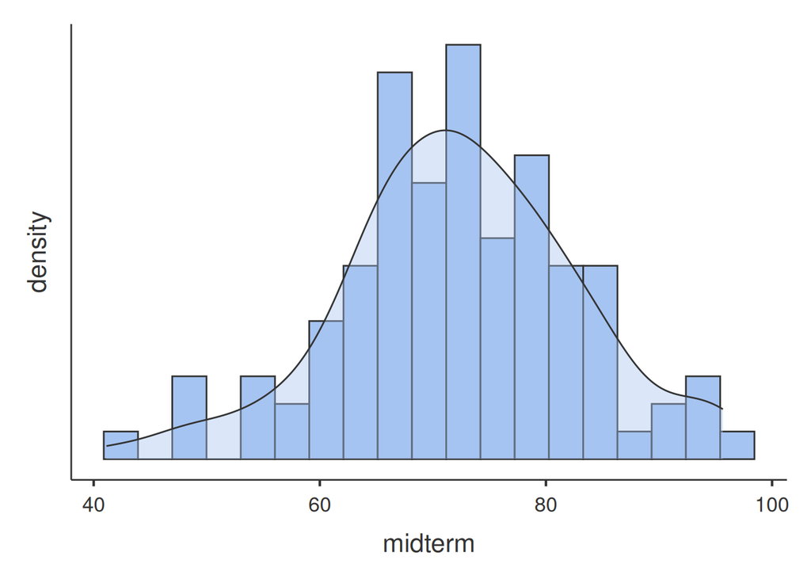

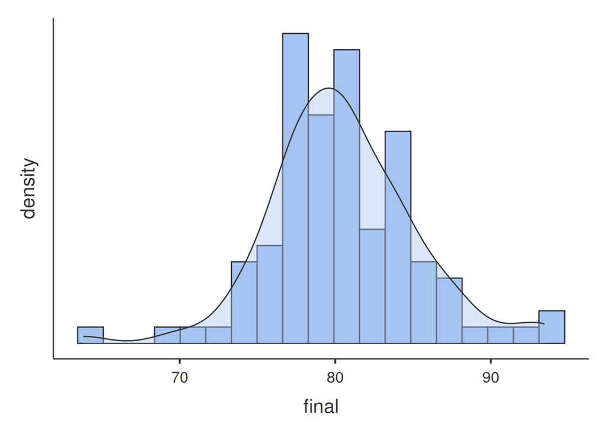

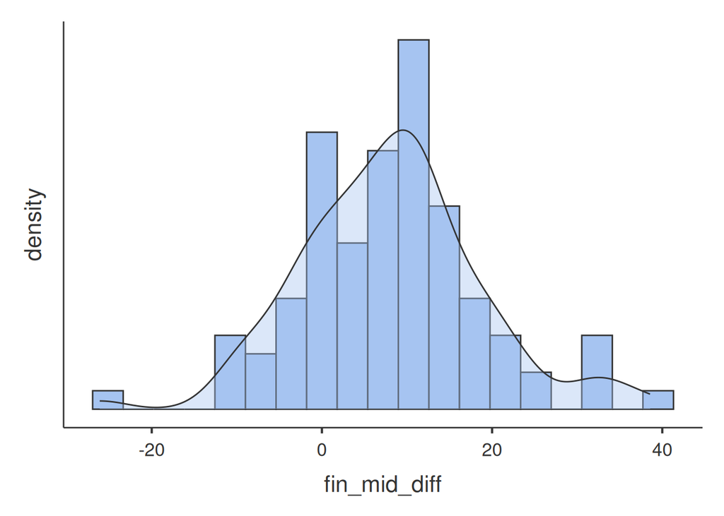

```r
# We're going to create a descriptives object so we can checkout the histogram
# and descriptive stats of the midterm scores, the final scores, and the
# diff of both.
rq1_desc <- jmv::descriptives( rq1_dat[2:4],
                               hist = TRUE,
                               dens = TRUE,
                               sd = TRUE,
                               variance = TRUE,
                               se = TRUE,
                               skew = TRUE,
                               kurt = TRUE
                             )

# Render the rq1 descriptives object as output.
rq1_desc
```

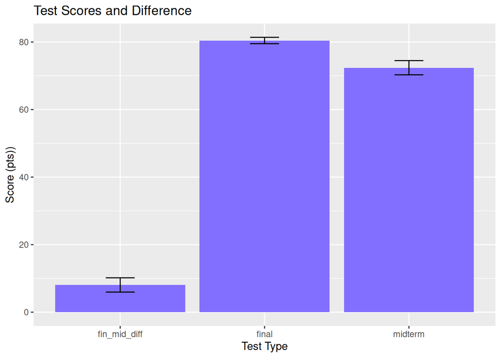

```r
# Now we're going to create a bar chart of the midterm scores, final scores,
# and diffs .. though the diffs data willbe oddly scaled (much smaller) than the
# raw scores

# In order to plot the scores as bar charts, we need to permute the data so all
# scores are in one vector and there's n indy axis vector of the same size that
# defines whether the score is a midterm score, final score, or difference.
# We use pivot_longer to concatenate the three dcore vectors to each other
# (interleaved), with the column names saved in the new "name" vector.
rq1_long <- rq1_dat[2:4] %>%
            pivot_longer(cols = c(midterm, final, fin_mid_diff) )

# We're going to lay all three datasets out on a single bar graph
# even though that may jackup the scaling to be bad for the diff.
bar_rq1 <- ggplot( rq1_long, aes(name, value) )



# Annotate the ggplot object to make a bar graph of test scodes.
bar_rq1 + stat_summary( fun = mean,
                        geom = "bar",
                        position = "dodge",
                        fill="slateblue1"
                      ) +
          stat_summary( fun.data = mean_cl_normal,
                        geom = "errorbar",
                        position = position_dodge(width = 0.90),
                        width = 0.2
                      ) +
          labs(x = "Test Type", y = "Score (pts))") +
          ggtitle('Test Scores and Difference')
```

##### Discussion of Visualization for RQ1

It is notable that the error bar on the final scores is so much tighter than  
that of the midterm scores. This is reflected in the final scores histogram  
which looks less “spread out” (smaller variance) than the same of the midterm  
scores. The larger spread in the differences of scores is also accounted for  
by the larger spread in the midterms as the tighter final scores minus the  
more spread out midterm scores will result in more spread out differences.

### Question 05 (Q05):

5. Did student test scores improve significantly from the midterm to the final?  
   Using RStudio to analyze, conduct a hypothesis test to evaluate this  
   question. Organize your answer according to the 4 steps of hypothesis  
   testing.

#### Answer to Q05:

##### Question 05 T-Test Code:

The code below runs the t-test by feeding the final and midterm scores, not the  
manually written diff above, to the t-test algorithm for paired samples. The  
organization of the results of this t-test, according to the 4 steps of NHST are  
in the next section.

```r
# We use the ttestPS to conduct a paired samples t-test from the jamovi (jmv)
# package. We want to include the effect size, confidence intervals, the
# means of our inputs, the standard errors, and the descriptive statistics in
# out output.
# NOTE: we supply "final" scores as i1 instead of i2 because that seems to
#       give the same directionality in mean difference in what we found
#       in our descriptive stats above.
rq1_test_results <- jmv::ttestPS( data = rq1_dat,
                                 pairs = list(list(i1='final', i2='midterm')),
                                 effectSize = TRUE,
                                 ci = TRUE,
                                 meanDiff = TRUE,
                                 desc = TRUE
                                )
# Dump the test results to output
rq1_test_results
```

```
##
##  PAIRED SAMPLES T-TEST
##
##  Paired Samples T-Test
##  ──────────────────────────────────────────────────────────────────────────────────────────────────────────────────────────────────────────────────────────────────
##                                       statistic    df          p             Mean difference    SE difference    Lower       Upper                    Effect Size
##  ──────────────────────────────────────────────────────────────────────────────────────────────────────────────────────────────────────────────────────────────────
##    final    midterm    Student's t     7.571237    99.00000    < .0000001           8.061300         1.064727    5.948651    10.17395    Cohen's d      0.7571237
##  ──────────────────────────────────────────────────────────────────────────────────────────────────────────────────────────────────────────────────────────────────
##    Note. Hₐ μ <sub>Measure 1 - Measure 2</sub> ≠ 0
##
##
##  Descriptives
##  ────────────────────────────────────────────────────────────────────
##               N      Mean        Median      SD           SE
##  ────────────────────────────────────────────────────────────────────
##    final      100    80.45750    80.22500     4.742058    0.4742058
##    midterm    100    72.39620    72.16500    10.601257    1.0601257
##  ────────────────────────────────────────────────────────────────────
```

```r
# save the test results in a dataframe object for use later
rq1_test_df <- rq1_test_results$ttest$asDF
```

##### Question 05 Discussion

To perform the significance test we use the SCEC acronym to remember our steps:  
Specify, Criteria, Estimate, Conclude:

1. **Specify** the Hypotheses:
   1. *Null Hypothesis:* Student test scores did **not** significantly change  
      between the midterm and the final.
   2. *Alternative Hypothesis*: Student test scores dd change significantly  
      between the midterm and the final.

   $H_{0}:\ \mu_{diff}\ =\ 0$  
   $H_{1}:\ \mu_{diff}\ \neq\ 0$
2. **Criteria:** We will check for significance using a two-tailed t-test with  
   *alpha* set to .05. Our degrees of freedom will be equal to the number of  
   samples we can take differences between, $n_{diff}$ (a.k.a. the number of  
   things we know), minus the number of things we’re estimating, in this case  
   the mean difference in scores from the population, of which there is 1.  
   So: $df\ =\ n_{diff}\ -\ 1$  
   $df\ =\$ 100 $\ -\ 1$  
   $df\ =\$ 99  
   … which gives us a $t_{crit}$ of 1.984

   $\alpha\ =\ .05$  
   $df\ =\ 99$  
   $t_{crit}\ =\ 1.984$
3. **Estimate:** Given the test conducted in the R-code above, we found the  
   following t-test results. Please note that all values printed below are  
   generated in text, on the fly, using the embedded r/tex-code shown after the  
   printout:

   $\bar{x}_{diff}\ =\$ 8.0613  
   $ESE_{diff}\ =\$ 1.064727  
   $t_{calc}\ =\$ 7.5712366  
   p < .000001  
   $d\ =\$ 0.7571237  
   $\eta^2\ =\$ 0.3666984

   *Verbatim Code:*

   ```
   $\bar{x}_{diff}\ =\ $ `\r rq1_test_df$'md[stud]'`
   $ESE_{diff}\ =\ $ `\r rq1_test_df$'sed[stud]'`
   $t_{calc}\ =\ $ `\r rq1_test_df$'stat[stud]'`
   `\r if( rq1_test_df$'p[stud]' >= 0.000001 ){ paste("p =", str_sub(sprintf("%.3f", rq1_test_df$'p[stud]'), -4 ) ) }else{ "p < .000001" }`
   $d\ =\ $ `\r rq1_test_df$'es[stud]'`
   $\eta^2\ =\ $ `\r rq1_test_df$'stat[stud]'^2 / (rq1_test_df$'stat[stud]'^2 + rq1_test_df$'df[stud]')`
   ```

4. **Conclude:** Given that $t_{calc} > t_{crit}$ we reject $H_{0}$. The test  
   scores did change significantly between the midterm and the final. Given  
   that $\bar{x}_{diff}$ is positive when the midterm scores are subtracted  
   from the final scores, this indicates that the test scores significantly  
   improved between the midterm and the final.

### Question 06 (Q06):

6. Report your findings in APA format. (Hint: make sure to answer the research  
   question!)

#### Answer to Q06:

We conducted a dependent t-test to examine whether test scores improved between  
the midterm and final tests for a class of 100 students given required study  
techniques. We found that final test scores, after implementing the study  
techniques, were significantly improved (final, $\bar{x}\ =\ 80.46,\ SD\ =\ 4.74$)  
compared to midterm test scores before the study techniques were implemented  
(midterm, $\bar{x}\ =\ 72.40,\ SD\ =\ 10.60$), t(99) = 7.57, p < .001, $\eta^2$ = .37.  
This was a large effect; the introduction of study techniques accounted for 37%  
of variance in the test score differences.

## Research Question 2 (RQ2): Q07 - Q09:

**Does the study technique used predict scores on the final exam?**  
**Data:** *308A.RQ2 Data.DA4.csv*

### Question 07 (Q07):

7. Visualize your data for this research question. Include your visualization  
   here.

#### Answer to Q07:

##### Loading Data for Q07:

The first step to visualizing the data is to load it. See code below:

```r
# In order to visualize the data we must first load it. To do so we look
# in the present working directory for CSV files, and take the one that
# has RQ2 in its filename. Append it to the current working directory
# to create the fullpath for loading
here <- getwd()
rq2_name <- list.files(here, pattern = ".*RQ2.*csv")

# Use the file.path function to create a platform appropriate fullpath / filename
# to the Research Question 2 data.
rq2_file <- file.path(here, rq2_name)

# Read the CSV data in as rq1_dat
rq2_dat <- read.csv(rq2_file, header = TRUE)

# Lower-case all column names for convenience
colnames(rq2_dat) <- tolower(colnames(rq2_dat))
```

##### Data Prep Q07

Ultimately we’re going to answer Research Question 2 as an independent t-test  
since we’re evaluating differences in test scores between the study technique  
employed by Group A and that by Group B. Since we’re not looking at matched  
samples between groups (i.e. the same students are not in both groups) there  
is no math to do here. We just need to make sure the group category is set to  
the correct datatype (factor). We also rename the categories as “A” and “B”  
are not particularly descriptive. See code below:

```r
# Recast the variables in the "group" vector to be factors instead of freeform
# character strings
rq2_dat$group <- as.factor(rq2_dat$group)

# Rename group "A" to A_group_study and group "B" to "B_flashcards"
levels(rq2_dat$group) <- sub("A", "A_group_study", levels(rq2_dat$group))
levels(rq2_dat$group) <- sub("B", "B_flashcards", levels(rq2_dat$group))
```

##### Visualize Prepared Data Q07 - Descriptives and Bar Chart

See the histograms below for visualization of the data pertinent to this  
research question (RQ2). Bar graphs of the final scores for Group A and Group B  
are also shown for better understanding.

```
##
##  DESCRIPTIVES
##
##  Descriptives
##  ──────────────────────────────────────────────────────
##                           group            final
##  ──────────────────────────────────────────────────────
##    N                      A_group_study            50
##                           B_flashcards             50
##    Missing                A_group_study             0
##                           B_flashcards              0
##    Mean                   A_group_study      81.25500
##                           B_flashcards       79.66000
##    Std. error mean        A_group_study     0.8349668
##                           B_flashcards      0.4307366
##    Median                 A_group_study      80.94000
##                           B_flashcards       79.78500
##    Standard deviation     A_group_study      5.904107
##                           B_flashcards       3.045768
##    Variance               A_group_study      34.85848
##                           B_flashcards       9.276702
##    Minimum                A_group_study      63.80000
##                           B_flashcards       69.54000
##    Maximum                A_group_study      93.46000
##                           B_flashcards       85.75000
##    Skewness               A_group_study    -0.1407758
##                           B_flashcards     -0.5920366
##    Std. error skewness    A_group_study     0.3366007
##                           B_flashcards      0.3366007
##    Kurtosis               A_group_study     0.5314386
##                           B_flashcards       1.417350
##    Std. error kurtosis    A_group_study     0.6619084
##                           B_flashcards      0.6619084
##  ──────────────────────────────────────────────────────
```

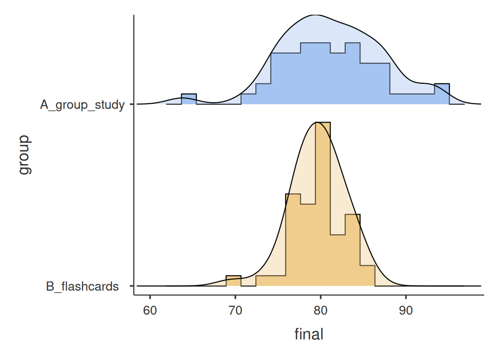

```r
# We're going to create a descriptives object so we can checkout the histogram
# and descriptive stats of the final scores split by Group. Since we have the
# descriptives available for all final scores combined from RQ1 above, we
# won't recreate that here.
rq2_desc <- jmv::descriptives( rq2_dat,
                               vars = c('final'),
                               splitBy = c('group'),
                               hist = TRUE,
                               dens = TRUE,
                               sd = TRUE,
                               variance = TRUE,
                               se = TRUE,
                               skew = TRUE,
                               kurt = TRUE
                             )

# Render the rq2 descriptives object as output.
rq2_desc
```

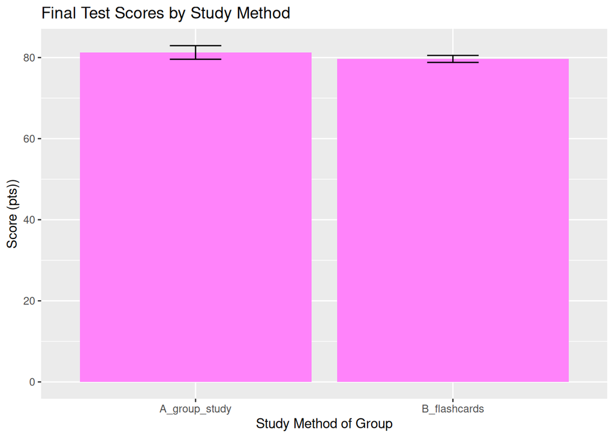

```r
# Now we're going to create a bar chart of the final scores sorted by group.
# No pivoting is needed here as data is already properly formatted.

# First we create the bar chart ggplot object via associating the group with
# the scores as an aesthetic object (aes)
bar_rq2 <- ggplot( rq2_dat, aes(group, final) )

# Now we annotate the bar chart appropriately. Bars will be colored orchid.
# error bars will be added.
bar_rq2 + stat_summary( fun = mean,
                        geom = "bar",
                        position = "dodge",
                        fill="orchid1"
                      ) +
          stat_summary( fun.data = mean_cl_normal,
                        geom = "errorbar",
                        position = position_dodge(width = 0.90),
                        width = 0.2
                      ) +
          labs(x = "Study Method of Group", y = "Score (pts))") +
          ggtitle('Final Test Scores by Study Method')
```

##### Discussion of Visualization for RQ2

The study technique employed by Group B, using flashcards for memorization,  
produced less spread in test scores for that group, however, the mean final test  
scores were remarkably similar to those of Group A. Despite this, the study  
technique employed by Group A, studying in groups right before the final exam  
had more spread out test scores (higher variance / standard deviation). I’ll  
be surprised if the difference in means between these two groups is significant.

### Question 08 (Q08):

8. Does the study technique used predict scores on the final exam? Using  
   RStudio to analyze, conduct a hypothesis test to evaluate this question.  
   Organize your answer according to the 4 steps of hypothesis testing.

#### Answer to Q08:

##### Question 08 T-Test Code:

The code below runs the t-test by feeding the final test scores to the t-test  
algorithm for independent samples. The organization of the results of this  
t-test, according to the 4 steps of NHST are in the next section.

```r
# We use the ttestIS to conduct an independent t-test from the jamovi (jmv)
# package. We want to include the effect size, confidence intervals, the
# means of our inputs, the standard errors, and the descriptive statistics in
# out output.
rq2_test_results <- jmv::ttestIS( data = rq2_dat,
                                 vars = 'final',
                                 group = 'group',
                                 effectSize = TRUE,
                                 ci = TRUE,
                                 meanDiff = TRUE,
                                 desc = TRUE
                                )
# Dump the test results to output
rq2_test_results
```

```
##
##  INDEPENDENT SAMPLES T-TEST
##
##  Independent Samples T-Test
##  ─────────────────────────────────────────────────────────────────────────────────────────────────────────────────────────────────────────────────────────
##                            Statistic     df          p            Mean difference    SE difference    Lower         Upper                    Effect Size
##  ─────────────────────────────────────────────────────────────────────────────────────────────────────────────────────────────────────────────────────────
##    final    Student's t    1.697670 ᵃ    98.00000    0.0927436           1.595000        0.9395231    -0.2694530    3.459453    Cohen's d      0.3395340
##  ─────────────────────────────────────────────────────────────────────────────────────────────────────────────────────────────────────────────────────────
##    Note. Hₐ μ <sub>A_group_study</sub> ≠ μ <sub>B_flashcards</sub>
##    ᵃ Levene's test is significant (p < .05), suggesting a violation of the assumption of equal variances
##
##
##  Group Descriptives
##  ─────────────────────────────────────────────────────────────────────────────────
##             Group            N     Mean        Median      SD          SE
##  ─────────────────────────────────────────────────────────────────────────────────
##    final    A_group_study    50    81.25500    80.94000    5.904107    0.8349668
##             B_flashcards     50    79.66000    79.78500    3.045768    0.4307366
##  ─────────────────────────────────────────────────────────────────────────────────
```

```r
# save the test results in a dataframe object for use later
rq2_test_df <- rq2_test_results$ttest$asDF
```

##### Question 08 Discussion

To perform the significance test we use the SCEC acronym to remember our steps:  
Specify, Criteria, Estimate, Conclude:

1. **Specify** the Hypotheses:
   1. *Null Hypothesis:* There is **no** difference between the final test  
      scores of students using the Group A study technique vs. students  
      using the Group B study technique.
   2. *Alternative Hypothesis*: There mean of Group A’s final scores is  
      different than the mean of Group B’s final scores.

   $H_{0}:\ \mu_{A}\ =\ \mu_{B}$  
   $H_{1}:\ \mu_{A}\ \neq\ \mu_{B}$
2. **Criteria:** We will check for significance using a two-tailed t-test with  
   *alpha* set to .05. Our degrees of freedom will be equal to the total number  
   of students between both groups, $n_{A} + n_{B}$ (a.k.a. the number of  
   things we know), minus the number of things we’re estimating, in this case  
   the mean of the final test scores for Group A and the mean of the final  
   test scores for Group B, or two items.  
   So: $df\ =\ n_{students}\ -\ 2$  
   $df\ =\$ 100 $\ -\ 2$  
   $df\ =\$ 98  
   … which gives us a $t_{crit}$ of 1.984

   $\alpha\ =\ .05$  
   $df\ =\ 98$  
   $t_{crit}\ =\ 1.984$
3. **Estimate:** Given the test conducted in the R-code above, we found the  
   following t-test results. Please note that all values printed below are  
   generated in text, on the fly, using the embedded r/tex-code shown after the  
   printout:

   $\bar{x}_{A}\ -\ \bar{x}_{B}\ =\$ 1.595  
   $ESED\ =\$ 0.9395231  
   $t_{calc}\ =\$ 1.6976698  
   p = .093  
   $d\ =\$ 0.339534  
   $\eta^2\ =\$ 0.0285688

   *Verbatim Code:*

   ```
   $\bar{x}_{A}\ -\ \bar{x}_{B}\ =\ $ `\r rq2_test_df$'md[stud]'`
   $ESED\ =\ $ `\r rq2_test_df$'sed[stud]'`
   $t_{calc}\ =\ $ `\r rq2_test_df$'stat[stud]'`
   `\r if( rq2_test_df$'p[stud]' >= 0.000001 ){ paste("p =", str_sub(sprintf("%.3f", rq2_test_df$'p[stud]'), -4 ) ) }else{ "p < .000001" }`
   $d\ =\ $ `\r rq2_test_df$'es[stud]'`
   $\eta^2\ =\ $ `\r rq2_test_df$'stat[stud]'^2 / (rq2_test_df$'stat[stud]'^2 + rq2_test_df$'df[stud]')`
   ```

4. **Conclude:** Given that $t_{calc}\ <\ t_{crit}$ we fail to reject $H_{0}$.  
   The mean final test scores **did not** vary significantly between Group A  
   and Group B. We failed to find a significant difference in study technique  
   impact on final test scores.

### Question 09 (Q09):

9. …
   1. Report your findings in APA format. (Hint: make sure to answer the  
      research question!)

#### Answer (9.b):

      We required students to try one of two study techniques between the  
      midterm and the final of our psychology course to determine which  
      technique, if any, was better at improving test scores. We found that  
      both techniques, studying in groups just before the final, and using  
      flashcards to improve memorization, significantly improved test scores.  
      The study techniques accounted for 37% of the improvement measured in  
      test scores. However, we also found that neither study technique was  
      notably better than the other. So students could use either or both  
      techniques to improve scores.

# Question 10 (Q10):

10. A developmental psychologist is interested in the effect of a positive  
    psychology intervention on the well-being of aging adults. She administers  
    the intervention, collects well-being scores from a sample of 100  
    participants, and tests whether their well-being differs significantly from  
    the national average. Using G*Power, she determines the power for her test  
    is .80.
    1. Interpret this value
    2. What suggestion would you give her if she wants a higher probability of  
       detecting a true effect?

## Answer to Q10:

### 10.a Answer:

It’s difficult to determine exactly what to make if the power value given  
by the researcher as the manner in which G*Power was used to calculate power  
is unclear. However, the G*Power manual does give at least one effect size  
index table in section 3.1 which indicates values above .50 should be  
be considered large. This is consistent with Cohen’s d, which is what G*Power  
validated against according to the User Manual. Therefore, we can, with some  
assumption, conclude that the developmental psychology did find a large effect  
of the intervention on the well-being of aging adults. We can’t say much  
more without knowing how, mathematically, the .80 was calculated.

### 10.b Answer:

If the researcher wanted a higher probability of detecting a true effect, I  
would suggest she run another study evaluating the intervention via a  
dependent-samples t-test method. That is, she should collect data on the  
well-being of the study participants **before** the intervention, and then  
collect the same data on the same participants **after** the intervention and  
subtract the two well-being scores. This would help eliminate other sources  
that may have impacted study participants well-being.

# Question 11 (Q11):

11. What would it mean if your analysis returned the following values? Consider  
    the meaning of t - not the decision associated with it.
    1. *t(24) = 0.35*
    2. *t(24) = 1.00*
    3. *t(24) = 3.2*

# Question 12 (Q12):

12. Draw and annotate all the properties of the null and alternative curves:  
    power, beta, alpha, type 1 error, type 2 error.